# Practical Machine Learning - Project

Samit Patnaik

13/08/2019

# Read training and testing data from the url(s) provided in the assignment. Assign the url(s) to variable to be able to read the data into csv file

```r
train_url <- "https://d396qusza40orc.cloudfront.net/predmachlearn/pml-training.csv"
test_url <- "https://d396qusza40orc.cloudfront.net/predmachlearn/pml-testing.csv"
download.file(url = train_url ,destfile = "training.csv")
download.file(url = test_url ,destfile = "testing.csv")
```

# Read training and testing data, identifying “”(empty fields), “NA” and “#DIV/0!” as “NA” everywhere

```r
train <- read.csv("training.csv",na.strings = c("NA","#DIV/0!",""))
test <- read.csv("testing.csv",na.strings = c("NA","#DIV/0!",""))
```

# Load the librariees

```r
library(caret)
```

```r
library(ggplot2)
library(randomForest)
library(rpart)
library(rpart.plot)
```

# Set aside 40 percent of the training data for cross validation purposes

```r
summary(train$classe)
```

```
##    A    B    C    D    E
## 5580 3797 3422 3216 3607
```

```r
inTrain <- createDataPartition(y=train$classe,p=0.6,list = FALSE)
myTrain <- train[inTrain,]
myTest <- train[-inTrain,]
```

## Cleaning Train and Test data . Delete columns with all missing values

```r
myTrain <- myTrain[,colSums(is.na(myTrain))==0]
myTest <- myTest[,colSums(is.na(myTest))==0]
head(colnames(myTrain), 10)
```

```
##  [1] "X"                    "user_name"            "raw_timestamp_part_1"
##  [4] "raw_timestamp_part_2" "cvtd_timestamp"       "new_window"
##  [7] "num_window"           "roll_belt"            "pitch_belt"
## [10] "yaw_belt"
```

*/ We can delete first 7 variables, because they are irrelevant to our project: “user_name”, “raw_timestamp_part_1”, “raw_timestamp_part_2”, “cvtd_timestamp”, “new_window” and “num_window” (columns 1 to 7). /*

```r
myTrain <- myTrain[,8:dim(myTrain)[2]]
myTest <- myTest[,8:dim(myTest)[2]]
```

# Plot some data before analysis

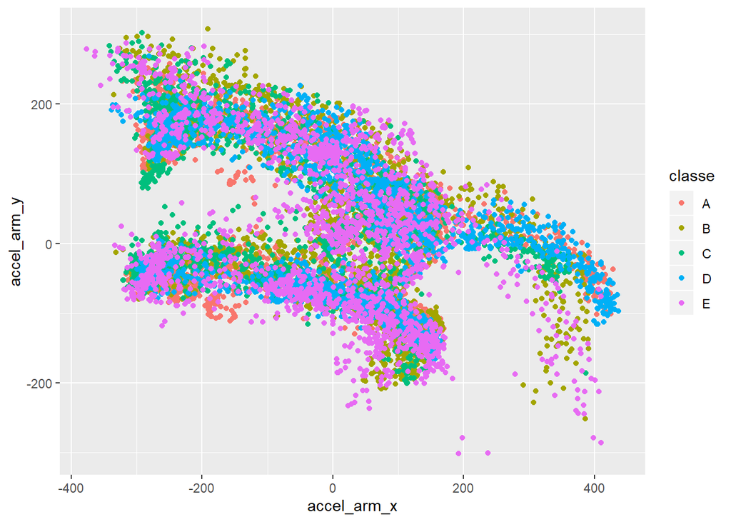

```r
qplot(accel_arm_x,accel_arm_y,col=classe,data=myTrain)
```

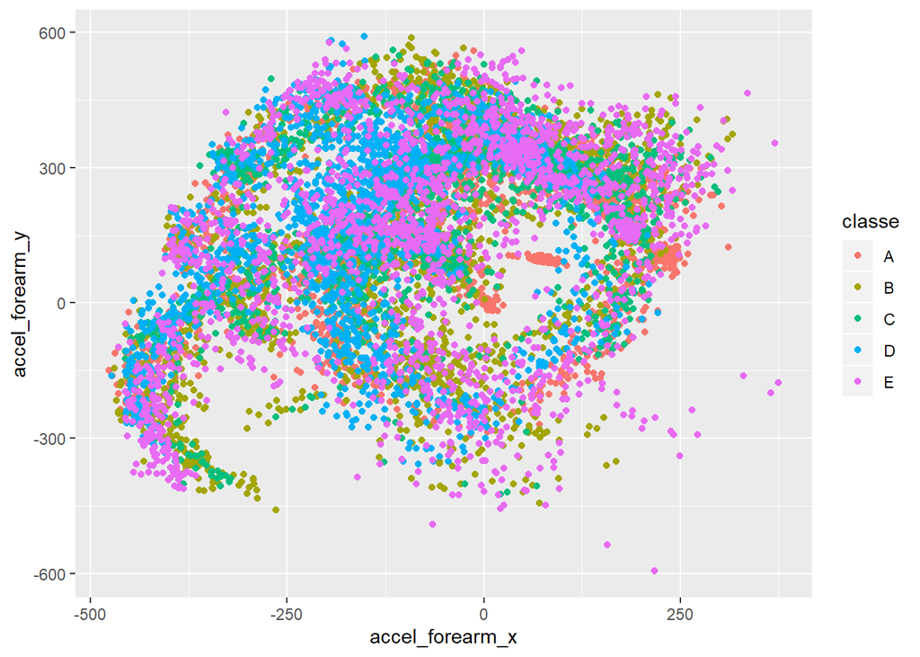

```r
qplot(accel_forearm_x, accel_forearm_y, col=classe, data=myTrain)
```

*/Plotting some accelaration data from train data, we can see that the pattern is very similar and hard to distinguish among classes A,B,C,D,E /* ## Predicting Models

# Apply Classification Tree Model

```r
modelCTree <- rpart(classe ~ ., data = myTrain , method = "class")
predictionCTree <- predict(modelCTree,myTest, type= "class")
confusionMatrix(predictionCTree,myTest$classe)
```

```
## Confusion Matrix and Statistics
##
##           Reference
## Prediction    A    B    C    D    E
##          A 1959  249   29   68   23
##          B   67  882  108  119  126
##          C   62  197 1108  190  161
##          D   74  121   78  827   74
##          E   70   69   45   82 1058
##
## Overall Statistics
##
##                Accuracy : 0.7436
##                  95% CI : (0.7337, 0.7532)
##     No Information Rate : 0.2845
##     P-Value [Acc > NIR] : < 2.2e-16
##
##                   Kappa : 0.6753
##
##  Mcnemar's Test P-Value : < 2.2e-16
##
## Statistics by Class:
##
##                      Class: A Class: B Class: C Class: D Class: E
## Sensitivity            0.8777   0.5810   0.8099   0.6431   0.7337
## Specificity            0.9343   0.9336   0.9058   0.9471   0.9585
## Pos Pred Value         0.8415   0.6774   0.6449   0.7044   0.7991
## Neg Pred Value         0.9505   0.9028   0.9576   0.9312   0.9411
## Prevalence             0.2845   0.1935   0.1744   0.1639   0.1838
## Detection Rate         0.2497   0.1124   0.1412   0.1054   0.1348
## Detection Prevalence   0.2967   0.1659   0.2190   0.1496   0.1687
## Balanced Accuracy      0.9060   0.7573   0.8579   0.7951   0.8461
```

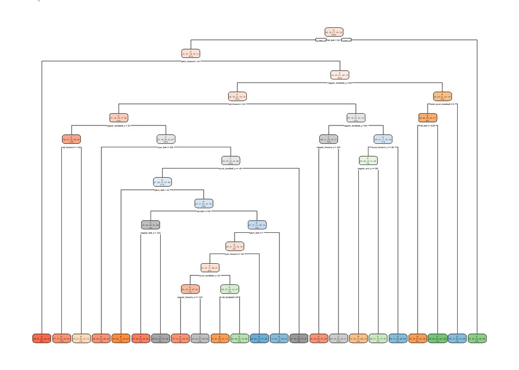

```r
rpart.plot(modelCTree)
```

# Apply Random Forest Models

```r
modelRF <- randomForest(classe ~ ., data=myTrain ,method="class")
predictionRF <- predict(modelRF , myTest , type = "class")
confusionMatrix(predictionRF,myTest$classe)
```

```
## Confusion Matrix and Statistics
##
##           Reference
## Prediction    A    B    C    D    E
##          A 2230   17    0    0    0
##          B    1 1499   16    0    0
##          C    0    2 1350   17    0
##          D    0    0    2 1266    6
##          E    1    0    0    3 1436
##
## Overall Statistics
##
##                Accuracy : 0.9917
##                  95% CI : (0.9895, 0.9936)
##     No Information Rate : 0.2845
##     P-Value [Acc > NIR] : < 2.2e-16
##
##                   Kappa : 0.9895
##
##  Mcnemar's Test P-Value : NA
##
## Statistics by Class:
##
##                      Class: A Class: B Class: C Class: D Class: E
## Sensitivity            0.9991   0.9875   0.9868   0.9844   0.9958
## Specificity            0.9970   0.9973   0.9971   0.9988   0.9994
## Pos Pred Value         0.9924   0.9888   0.9861   0.9937   0.9972
## Neg Pred Value         0.9996   0.9970   0.9972   0.9970   0.9991
## Prevalence             0.2845   0.1935   0.1744   0.1639   0.1838
## Detection Rate         0.2842   0.1911   0.1721   0.1614   0.1830
## Detection Prevalence   0.2864   0.1932   0.1745   0.1624   0.1835
## Balanced Accuracy      0.9980   0.9924   0.9920   0.9916   0.9976
```

# Adding a new column GoodPred to myTest_predindicator to determine predicted value for the test data vs true value in the test data

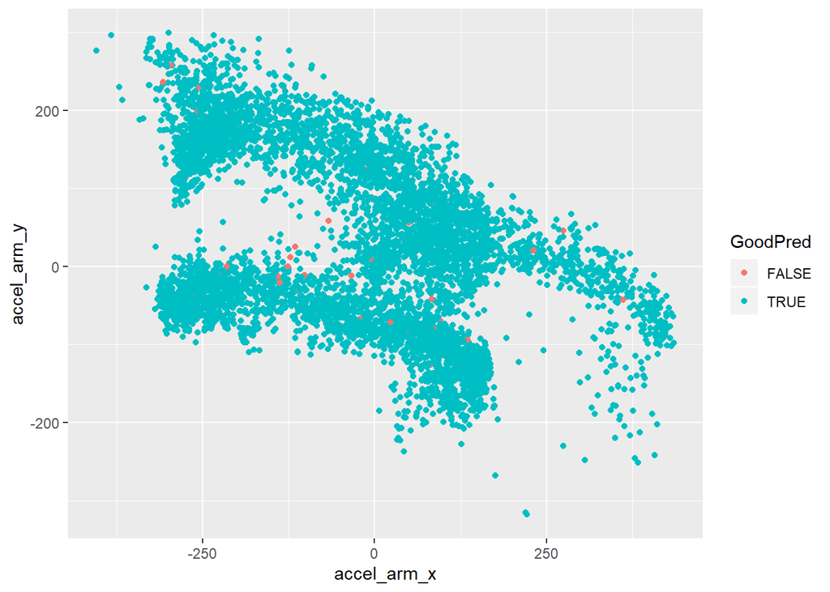

```r
myTest_predindicator <- myTest
myTest_predindicator$GoodPred <- myTest$classe == predictionRF

qplot(accel_arm_x,accel_arm_y,col=GoodPred,data=myTest_predindicator)
```

# Final Prediction

```r
 FinaPred <- predict(modelRF,test)
 table(t(data.frame(FinaPred)))
```

```
##
## A B C D E
## 7 8 1 1 3
```

```r
 FinaPred
```

```
##  1  2  3  4  5  6  7  8  9 10 11 12 13 14 15 16 17 18 19 20
##  B  A  B  A  A  E  D  B  A  A  B  C  B  A  E  E  A  B  B  B
## Levels: A B C D E
```

#Conclusion : Prediction evaluations were based on maximizing the accuracy and minimizing the out-of-sample error. All other available variables after cleaning were used for prediction. Two models were tested using decision tree and random forest algorithms. The model with the highest accuracy were chosen as final model.

# Random Forest Prediction is much more accurate then classification Tree model